# Previsione della sinistrosità per il ramo R.C. Auto

# 1 Analisi esplorativa

I dati provengono da un portafoglio di polizze R.C. Auto relative ad un anno di esercizio di una compagnia francese. Il dataset è composto da 678 013 polizze R.C. Auto e di 12 feature.

```
## 'data.frame':    678013 obs. of  12 variables:
##  $ IDpol     : num  1 3 5 10 11 13 15 17 18 21 ...
##  $ ClaimNb   : 'table' num [1:678013(1d)] 1 1 1 1 1 1 1 1 1 1 ...
##  $ Exposure  : num  0.1 0.77 0.75 0.09 0.84 0.52 0.45 0.27 0.71 0.15 ...
##  $ VehPower  : int  5 5 6 7 7 6 6 7 7 7 ...
##  $ VehAge    : int  0 0 2 0 0 2 2 0 0 0 ...
##  $ DrivAge   : int  55 55 52 46 46 38 38 33 33 41 ...
##  $ BonusMalus: int  50 50 50 50 50 50 50 68 68 50 ...
##  $ VehBrand  : Factor w/ 11 levels "B1","B10","B11",..: 4 4 4 4 4 4 4 4 4 4 ...
##  $ VehGas    : chr  "Regular" "Regular" "Diesel" "Diesel" ...
##  $ Area      : Factor w/ 6 levels "A","B","C","D",..: 4 4 2 2 2 5 5 3 3 2 ...
##  $ Density   : int  1217 1217 54 76 76 3003 3003 137 137 60 ...
##  $ Region    : Factor w/ 21 levels "Alsace","Aquitaine",..: 21 21 18 2 2 16 16 13 13 17 ...
```

| Feature | Descrizione | Tipo variabile | Dominio |
| --- | --- | --- | --- |
| IDpol | identificativo polizza |  |  |
| ClaimNb | numero sinistri | discreta | [0, 16] |
| Exposure | esposizione in anni | discreta | [0, 2] |
| Area | codice dell’area | categorica | 6 classi |
| VehPower | potenza del motore | discreta | [4, 15] |
| VehAge | età dell’auto | discreta | [0, 100] |
| DrivAge | età del conducente | discreta | [18, 100] |
| BonusMalus | livello di bonus-malus | continua | [50, 230] |
| VehBrand | marca dell’auto | categorica | 11 classi |
| VehGas | diesel o benzina | binaria | 2 classi |
| Density | densità di abitanti per km2 | discreta | [1, 27 000] |
| Region | regioni in Francia | categorica | 21 classi |

## 1.1 Numero di sinistri

Fra le 678 mila polizze considerate, solo 9 polizze hanno una sinistrosità superiore a 4; questi valori vengono considerati errori di rilevazione e posti pari a 4.

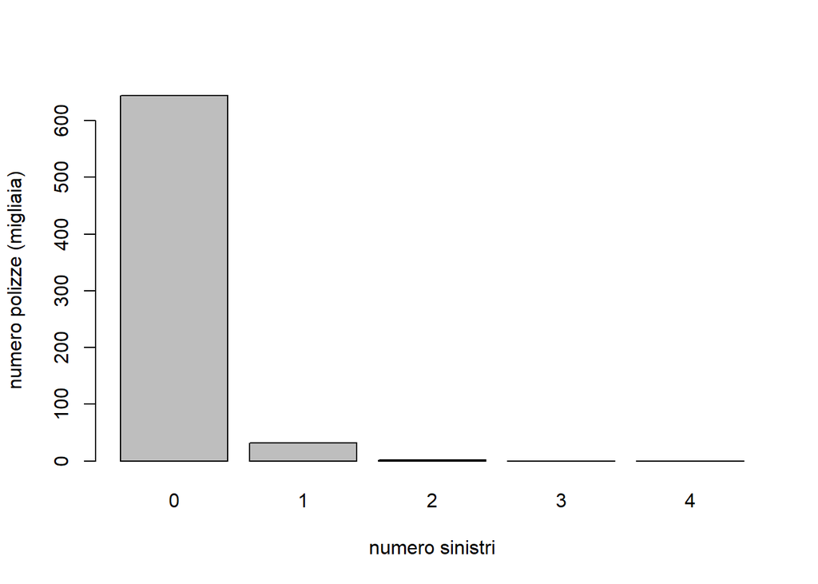

In media, circa il 5% degli assicurati denuncerà un sinistro durante l’anno di esercizio. La varianza della distribuzione è superiore al valore della media, indicando sovra-dispersione. Il coefficiente di asimmetria è positivo e pertanto la coda più lunga della distribuzione si ha in corrispondenza di valori superiori alla media. Il coefficiente di curtosi indica una distribuzione leptocurtica, dove un numero maggiore di osservazioni è concentrato attorno alla media rispetto alla distribuzione normale.

Table 1.1:

| n_polizze | media | varianza | asimmetria | curtosi |
| --- | --- | --- | --- | --- |
| 678013 | 0.05 | 0.06 | 4.76 | 25.32 |

## 1.2 Esposizione

L’esposizione è una misura del rischio di accadimento dell’evento assicurato, misurato in anni a rischio. Poichè il portafoglio considerato è relativo ad un solo anno di esercizio, le esposizioni superiori a un anno vengono considerate errori di rilevazione e poste pari a 1. Queste esposizioni sono probabilmente dovute ai rinnovi delle polizze in corso d’anno che vengono conteggiati come polizze aggiuntive.

## 1.3 Frequenza sinistri empirica

Per ciascuna feature, si calcola la frequenza sinistri

$$Y = \frac{N}{\nu}$$

condizionata alla feature $x_i$

$$f_i = E[ Y | X = x_i] = \frac{\sum_j N_{ij}}{\sum_j \nu_{ij}}, \hspace{1cm} j = 1, ..., 678013, i = 1, ..., k$$

dove $N = ClaimNb$, $\nu = Exposure$, e $k$ è uguale al numero di classi dell’i-esima feature.

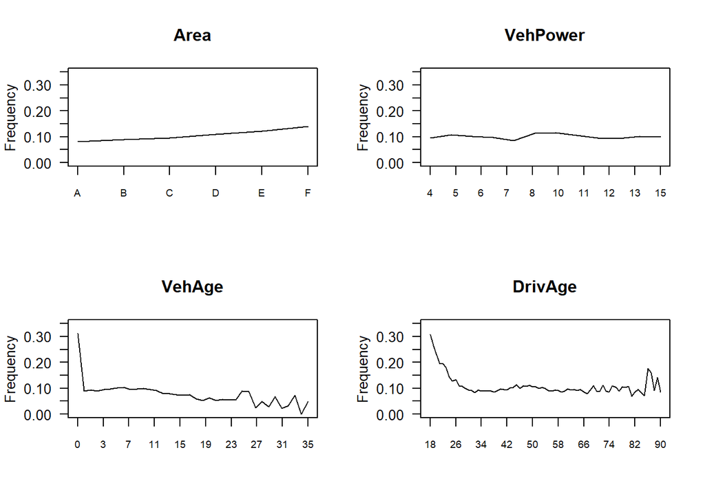

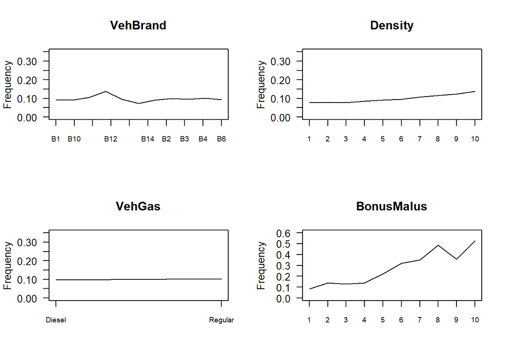

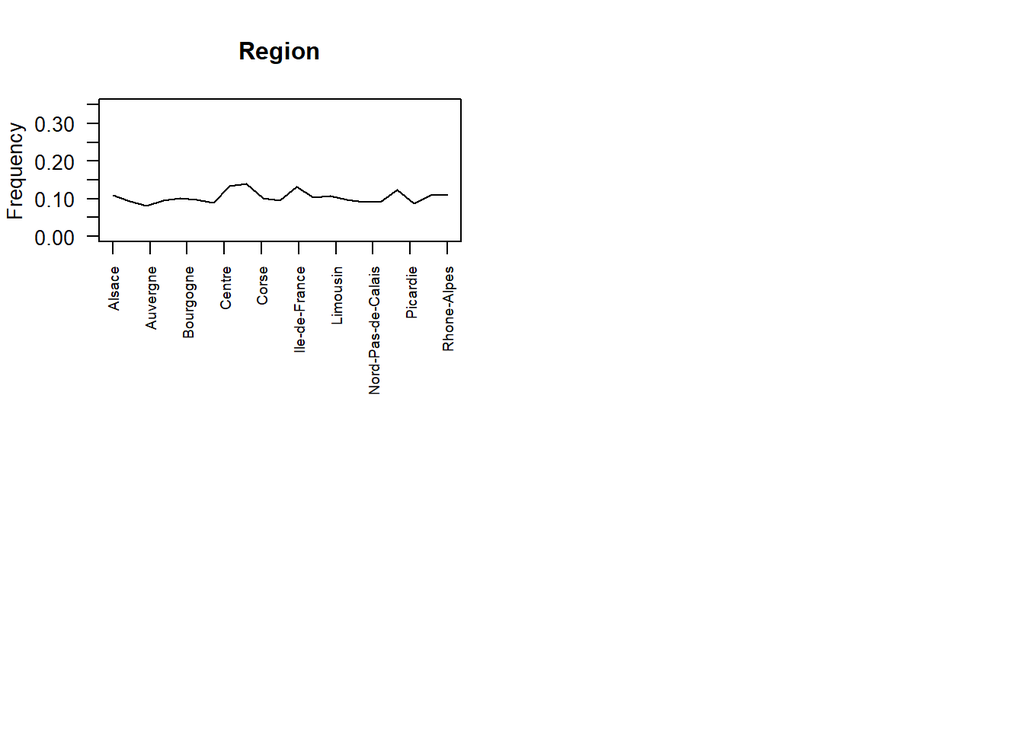

I valori di Density e BonusMalus sono stati suddivisi in 10 categorie a scopo illustrativo.

La frequenza sinistri è:

- monotona crescente per Area, indicando che la feature è ordinale;
- decrescente per VehAge;
- a forma di U per DrivAge fino all’età di circa 50 anni;
- crescente per i livelli BonusMalus;
- monotona crescente per Density;
- priva di un chiaro trend per VehPower, VehBrand e Region;

## 1.4 Sinistrosità totale

Per ognuna delle feature, calcoliamo il volume totale di sinistri

$$s_i = E[ N | X = x_i] = \sum_j N_{ij}, \hspace{1cm} j = 1, ..., 678013, i = 1, ..., k$$

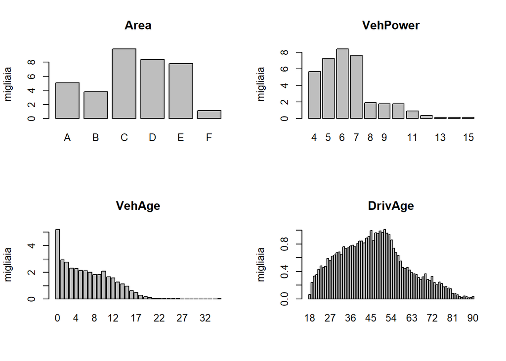

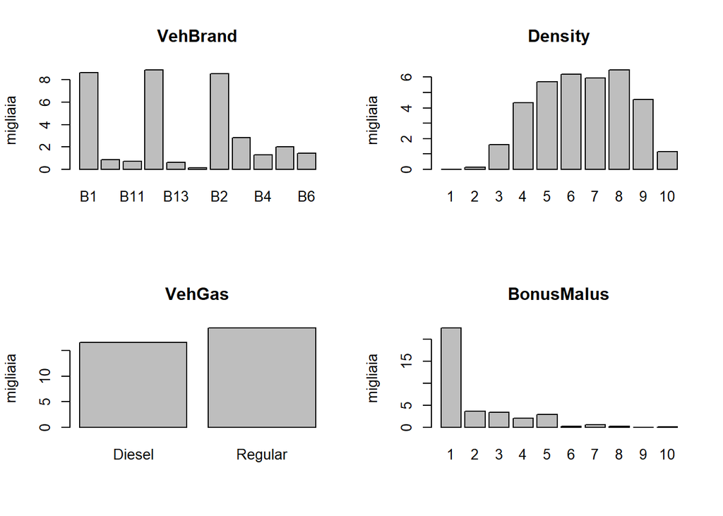

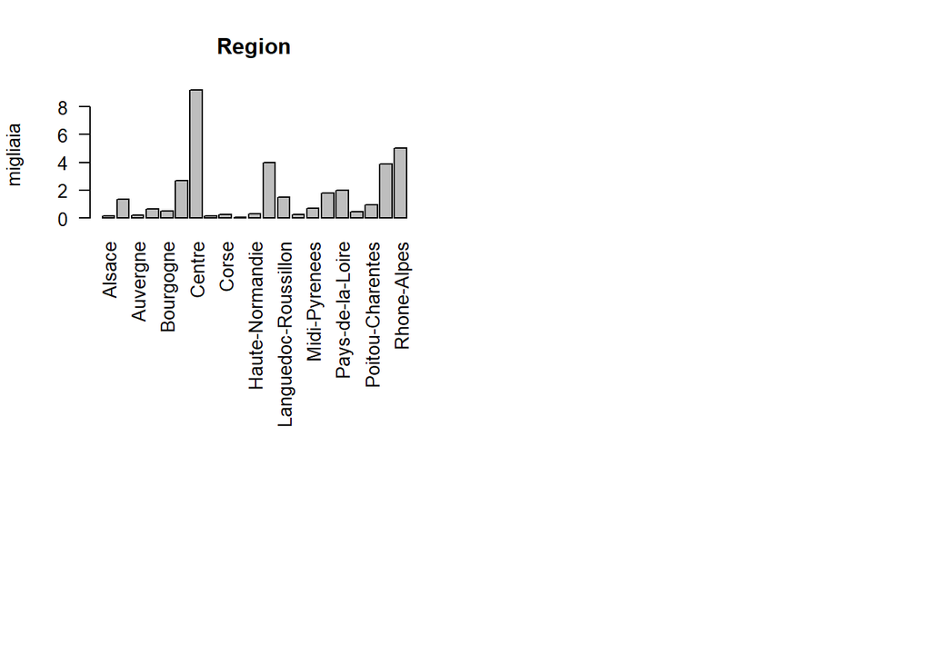

## 1.5 Correlazioni fra variabili

C’è una correlazione negativa fra il livello di Bonus-Malus e l’età dell’assicurato, mentre la densità abitativa è positivamente correlata con l’area, rendendo l’utilizzo di entrambe le feature ridondante.

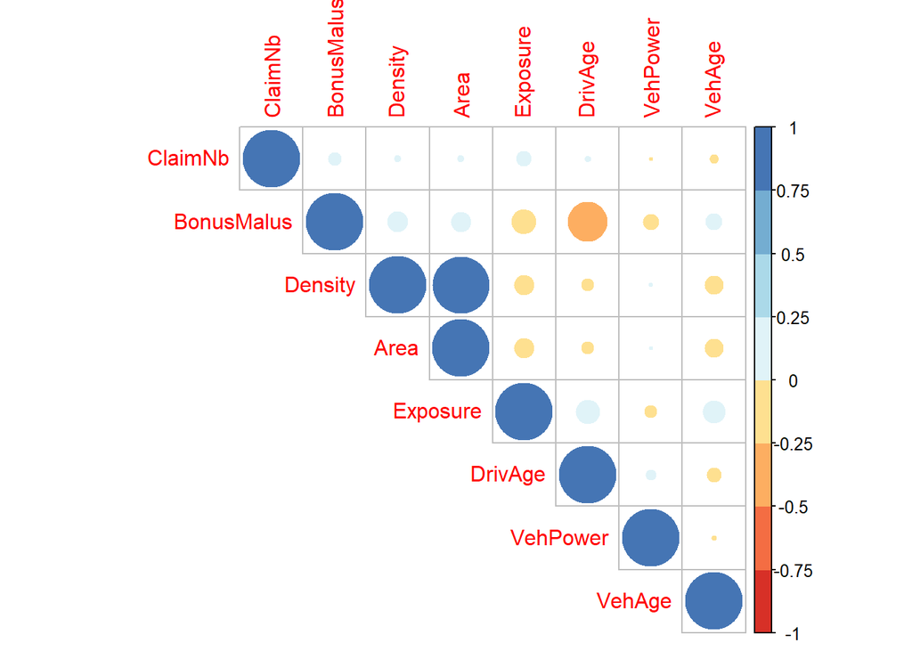

# 2 Generalized Linear Model

Consideriamo un vettore di 9 feature $x_i, i = 1, ..., n$ per ogni polizza RCA, contenente tutte le variabili eccetto l’identificativo della polizza (IDpol), il vettore di esposizioni $\nu_i = Exposure_i \in (0, 1]$ e il numero di sinistri $N_i = ClaimNb_i \geq 0$. Lo scopo è quello di ottenere una previsione del numero di sinistri $N_i$ utilizzando le feature rilevanti $x_i$ e le esposizioni $\nu_i$.

Assumiamo che ogni sinistro conteggiato $N_i$ segua una distribuzione di Poisson iid

$$N_i \sim Poisson(\lambda(x_i) \nu_i)$$

dove $\lambda$ è una funzione di regressione log-lineare che descrive la frequenza sinistri attesa

$$\begin{equation}
log \lambda(x) = \beta_0 + \sum_{l = 1}^{d} \beta_l x_l \tag{2.1}
\end{equation}$$

dove $\beta$ è un vettore di parametri.

Il dataset è suddiviso in training set $D$ e test set $T$ in modo tale da allocare il 90% delle polizze al training set e il restante 10% al test set.

Table 2.1: Frequenze empiriche

|  | Numero sinistri 0 | Numero sinistri 1 | Numero sinistri 2 | Numero sinistri 3 | Numero sinistri 4 | Totale |
| --- | --- | --- | --- | --- | --- | --- |
| training set | 94.97 | 4.75 | 0.27 | 0.01 | 0 | 5.33 |
| test set | 95.07 | 4.69 | 0.23 | 0.00 | 0 | 5.17 |

La loss function utilizzata è la devianza Poisson media:

$$\begin{equation}
L(D, \lambda) = \frac{1}{n} \sum_{i = 1}^n 2 N_i \left[ \frac{\lambda(x_i)\nu_i}{N_i} - 1 - log \left(\frac{\lambda(x_i)\nu_i}{N_i} \right) \right] \tag{2.2}
\end{equation}$$

Per sinistri con $N_i = 0$, il lato destro dell’equazione è posto uguale a $2\lambda(x_i)\nu_i$. La funzione di regressione ottimale $\hat{\lambda}(x_i)$ è stimata minimizzando la loss function rispetto a $\lambda$. In base alle assunzioni del modello, è possibile dimostrare che minimizzare la devianza Poisson media rispetto a $\lambda$ equivale a determinare lo stimatore di massima verosimiglianza di $\lambda$ (Wüthrich (2016)). La stima di $\hat{\lambda}$ è ottenuta utilizzando i dati nel training set $D$ ed è valutata out-of-sample sul test set $T$.

## 2.1 Feature pre-processing

La funzione di regressione (2.1) assume che tutte le feature abbiano valori reali. Si utilizza quindi un dummy encoding per convertire le variabili categoriche in numeriche. Questo metodo garantisce che la matrice delle feature abbia rango completo e, di conseguenza, che il MLE di $\beta$ in (2.1) sia unico o, equivalentemente, che la loss function (2.2) sia convessa (Wüthrich (2016)).

Scegliendo una classe come livello di riferimento (solitamente la più popolosa), il dummy encoding identifica univocamente k classi tramite un vettore di variabili dummy di dimensioni k-1, che ha un solo elemento uguale a 1 e i restanti uguali a 0.

Per le variabili VehPower, VehAge e DrivAge si costruiscono classi categoriche in base all’expert judgement (Wüthrich (2016)).

Ne risulta uno spazio delle feature $X$ con 47 dimensioni.

| Feature | Trasformazione | Dimensioni |
| --- | --- | --- |
| Area | variabile discreta | $[1, 6]$ |
| VehPower | 6 classi | $\{0, 1\}^5$ |
| VehAge | 3 classi | $\{0, 1\}^2$ |
| DrivAge | 7 classi | $\{0, 1\}^6$ |
| BonusMalus |  | $[50, 230]$ |
| VehBrand | 11 classi | $\{0, 1\}^{10}$ |
| VehGas | variabile binaria | $\{0, 1\}$ |
| Density | logaritmo | $[0, 11]$ |
| Region | 21 classi | $\{0, 1\}^{20}$ |

## 2.2 GLM con H2O e R base

Il modello GLM è stimato utilizzando il pacchetto H2O e il pacchetto stats di R.

Il pacchetto H2O utilizza un cluster su cui vegono caricati tutti gli oggetti disponibili nella sessione R corrente. Gli algoritmi sono implementanti in un framework Map/Reduce che utilizza il multi-threading. I dati sono processati in parallelo e distribuiti fra i nodi del cluster. Il codice core di H2O è scritto in Java.

Si specifica un numero di fold pari a 5 su cui effetture la convalida incrociata. Il modello è stimato sull’intero spazio delle feature, poichè le feature multicollineari sono individuate automaticamente dall’algoritmo di H2O, che pone il relativo coefficiente pari a zero. Si utilizzano altrimenti le impostazioni di default di H2O.

Le feature più importanti per la previsione della sinistrosità sono la classe di VehAge fino ad 1 anno, la classe di DrivAge da 26 a 30 anni e i livelli di BonusMalus. La variabile Area è stata posta pari a zero poichè altamente correlata con la variabile Density.

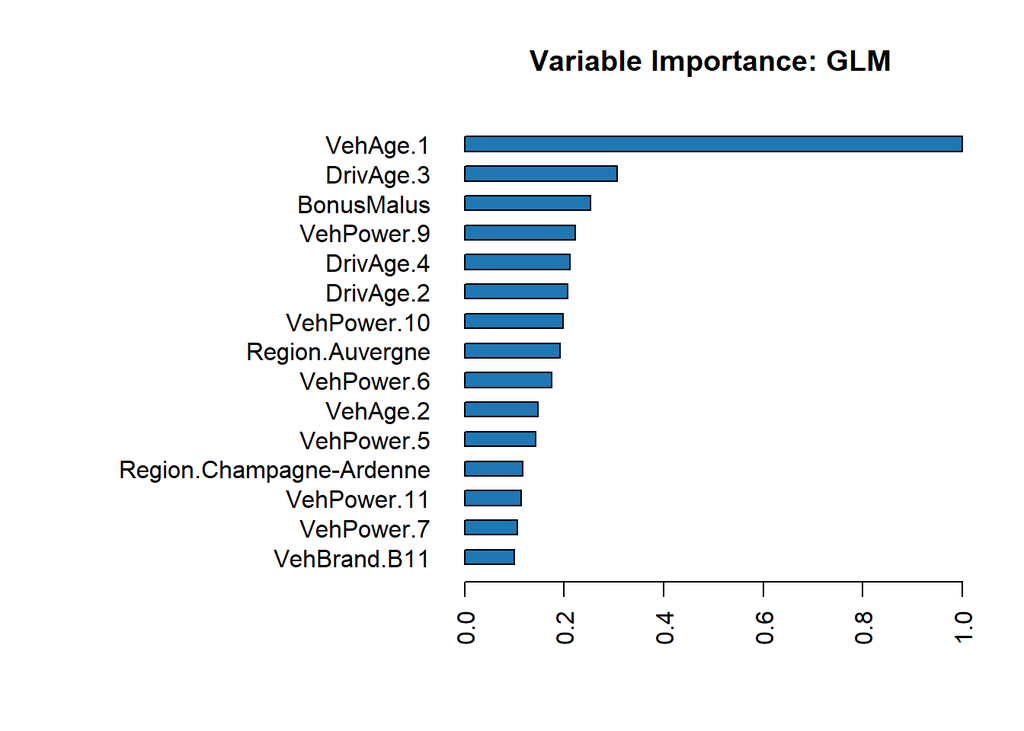

La sinistrosità aumenta all’aumentare dei livelli di BonusMalus, è massima per la prima classe di VehAge e minima per la terza classe di DrivAge.

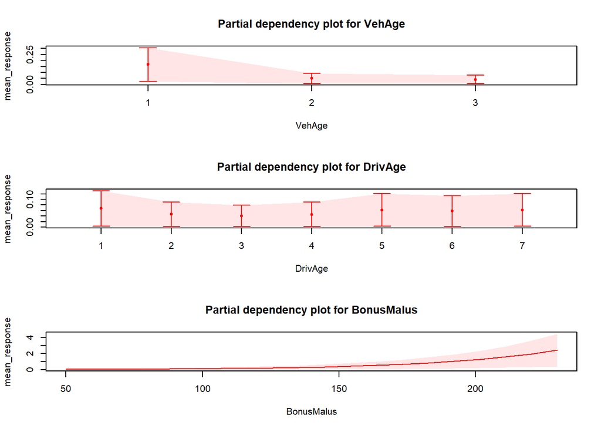

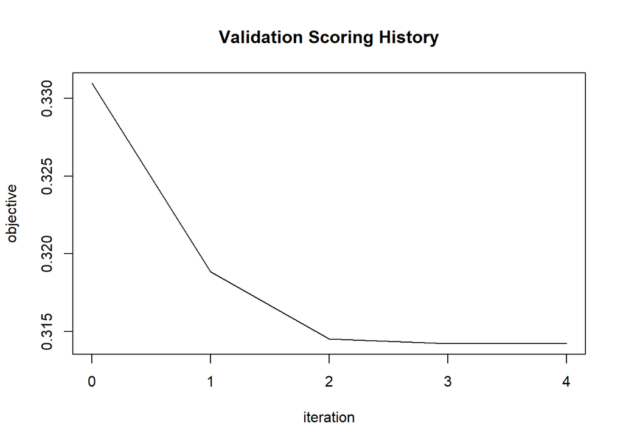

La performance del GLM è comparata con quella del modello benchmark $\hat{\lambda}\nu$ dove

$$\begin{equation}
\hat{\lambda} = \frac{\sum_{i = 1}^n N_i}{\sum_{i = 1}^n \nu_i} \tag{2.3}
\end{equation}$$

è il MLE della frequenza sinistri $\lambda$, ovvero il valore che minimizza la loss (2.2).

Il pre-processing delle feature migliora la capacità predittiva di circa un punto percentuale. La loss in sample è maggiore della loss out of sample, segno che non c’è overfitting.

Table 2.2: Mean Poisson Deviance

|  | in sample | cross validation | out of sample |
| --- | --- | --- | --- |
| benchmark | 33.1 |  | 32.4 |
| feature preprocessate | 31.41 | 31.43 | 30.92 |
| feature standardizzate | 32 | 32.02 | 31.33 |

I coefficienti e le previsioni ottenute con H2O e con R base sono molto simili. Le differenze sono dovute al fatto che in H2O il parametro di regolarizzazione è settato ad un valore diverso da zero di default.

Table 2.3: Confronto pesi

|  | pesi h2o | pesi R base |
| --- | --- | --- |
| VehAge.1 | 1.39 | 1.18 |
| DrivAge.3 | -0.42 | -0.42 |
| BonusMalus | 0.02 | 0.02 |

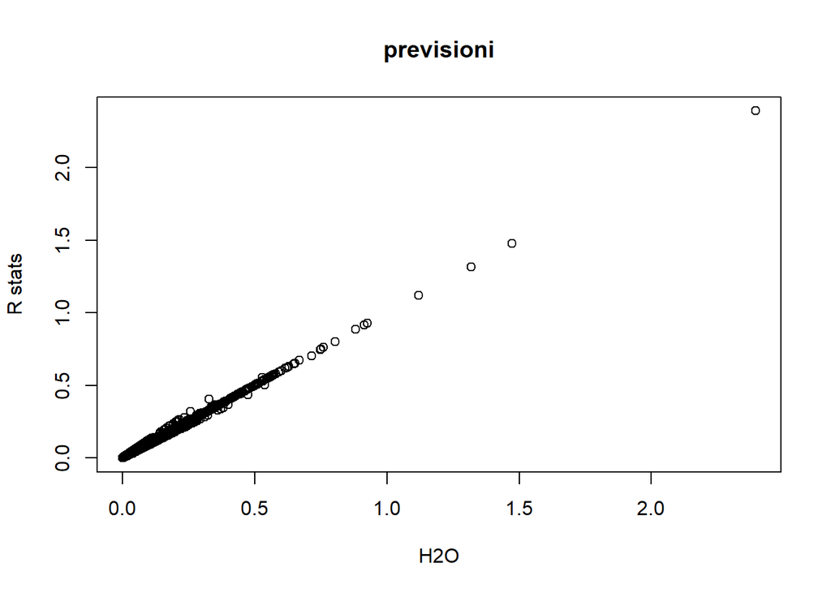

# 3 Poisson Boosting Machine con H2O

Contrariamente al caso dei GLM, che presuppongono una forma funzionale fissa per la frequenza sinistri attesa, gli alberi di regressione apprendono la forma strutturale ottimale dai dati nel training set.

Lo spazio delle features $X$ viene partizionato in maniera ottimale al fine di ottenere $K$ sottoinsiemi disgiunti $X_k, k = 1, ..., K$ di valori omogenei. Ad ogni livello dell’albero si sceglie, fra tutte le partizioni binarie possibili, quella che minimizza la loss function (2.2). La frequenza sinistri attesa sull’intero spazio delle feature $X$ è data da:

$$\hat{\lambda}(x) = \sum_{k = 1}^K \hat{\lambda}_k \mathrm{1}_{\{x \in X_k\}}$$

dove

$$\hat{\lambda}_k = \frac{\sum_{i = 1}^n \mathrm{1}_{\{x_i \in X_k\}} N_i}{\sum_{i = 1}^n \mathrm{1}_{\{x_i \in X_k\}} \nu_i}$$
è il MLE della frequenza sinistri sul sottoinsieme $X_k$.

Nel boosting si combinano molti alberi con poche foglie $K$ al fine di migliorare le capacità predittive del modello. I residui di ogni albero nella sequenza sono utilizzati come variabile dipendente per costruire l’albero successivo.

Le feature utilizzate negli alberi di regressione tipicamente non necessitano di pre-processing. Tuttavia spesso le feature categoriche con molte classi vengono trasformate in variabili numeriche per ridurre il carico computazionale.

In questo caso, si utilizzano i valori standardizzati delle feature e si lasciano gli iperparametri ai loro valori di default (ntrees = 50 e max_depth = 5).

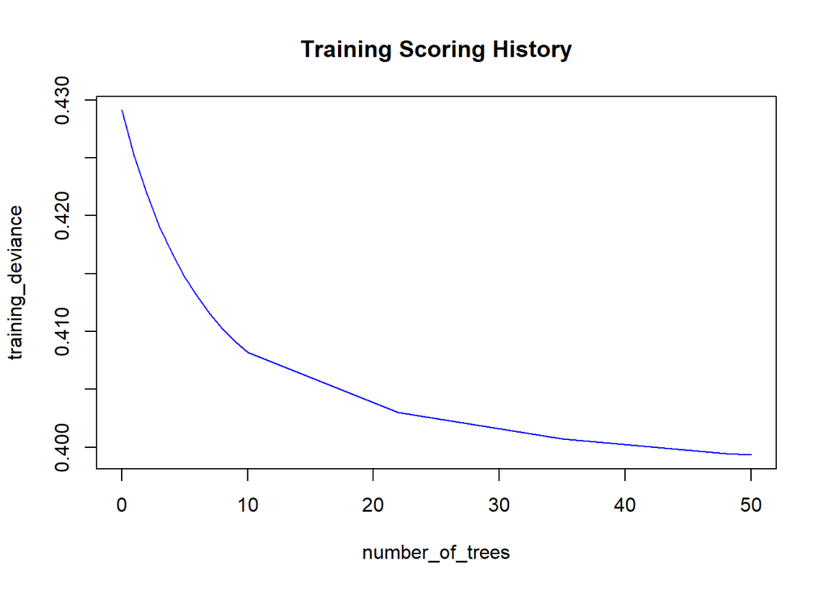

A differenza del GLM, dove veniva stimato un coefficiente per classe, nel GBM si considerano le feature aggregate. Le feature più importanti sono BonusMalus, VehAge e VehPower.

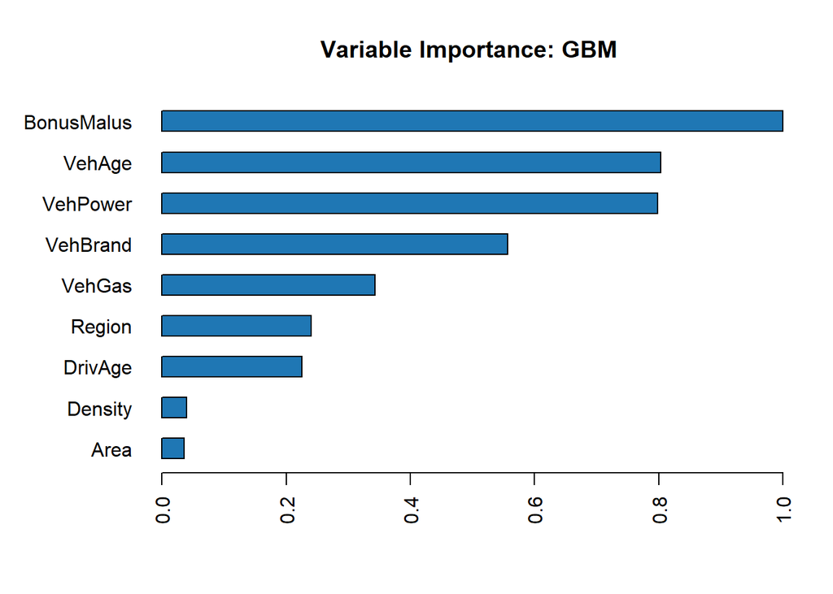

Si ottiene una performance migliore utilizzando i valori standardizzati delle feature anzichè il preprocessing precedente.

Table 3.1: Mean Poisson Deviance

|  | in sample | cross validation | out of sample |
| --- | --- | --- | --- |
| feature preprocessate | 30.25 | 30.58 | 30.06 |
| feature standardizzate | 30.12 | 30.45 | 29.94 |

## 3.1 Random Grid Search

Si selezionano i valori ottimali degli iperparametri allenando il modello su diversi valori e comparando le performance ottenute sul cross-validation set. Nella random grid search si testano diverse combinazioni di iperparametri estraendo ogni valore possibile in maniera aleatoria e indipendente.

Si utilizza una convalida incrociata 5-fold e si pone il tempo massimo di esecuzione pari a 15 minuti. Il numero di alberi è posto pari a 10 000 e si impone un criterio di early stopping: se la loss non migliora più dello 0.1% in 5 iterazioni, non vengono allenati ulteriori alberi.

Si ottimizzano il learning rate, la profondità massima dei singoli alberi, il sampling rate (la percentuale di osservazioni scelte casualmente per ogni albero) e il sampling rate delle colonne (la percentuale di feature scelte casualmente per ogni suddivisione).

```r
gbm_params <- list(learn_rate = seq(0.001, 0.3, 0.001),
                   max_depth = seq(2, 10),
                   sample_rate = seq(0.5, 1, 0.1),
                   col_sample_rate = seq(0.1, 1.0, 0.1))
```

```
## Hyper-Parameter Search Summary: ordered by increasing residual_deviance
##   col_sample_rate learn_rate max_depth sample_rate
## 1             0.8      0.193         5         0.5
## 2             0.1      0.258         3         0.8
## 3             0.6      0.261         9         0.8
##                                                        model_ids
## 1 Grid_GBM_learn_gbm_sid_9dcd_43_model_R_1615711610160_6_model_2
## 2 Grid_GBM_learn_gbm_sid_9dcd_43_model_R_1615711610160_6_model_3
## 3 Grid_GBM_learn_gbm_sid_9dcd_43_model_R_1615711610160_6_model_1
##     residual_deviance
## 1  0.4082053223256129
## 2  0.4121941462200242
## 3 0.45374247232461545
```

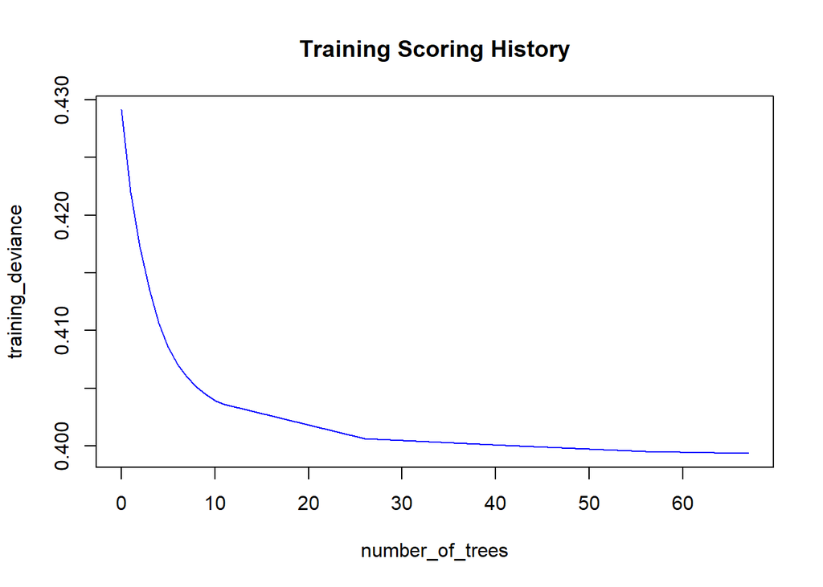

Le 3 feature più importanti sono le stesse del GBM senza random grid search, mentre la loss out of sample è leggermente più elevata.

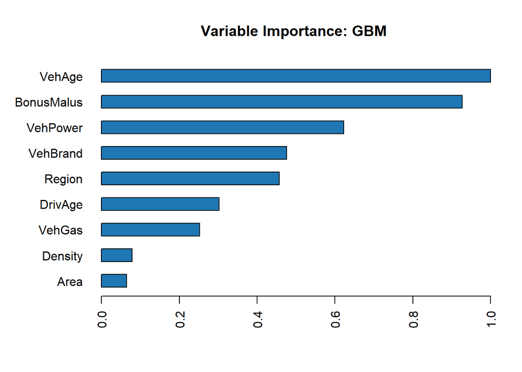

|  | in sample | cross validation | out of sample |
| --- | --- | --- | --- |
| Mean Poisson Deviance | 30.12 | 31.05 | 30.28 |

# 4 Shallow Neural Networks con Keras e H2O

Si consideri la funzione di regressione

$$log \lambda(x) = \beta_0 + \sum_{j = 1}^{q} \beta_j z_j(x)$$

dove $z_j^k(x), j = 1,...,q$ sono i neuroni del k-esimo hidden layer

$$z_j^k(x) = \phi \left(w_{j,0} + \sum_{l = 1}^{d} w_{j,l}^k x_l \right)$$

e $\theta^k= (\beta_0^k, ..., \beta_q^k, w_{1,0}^k, ..., w_{q,d}^k)$ sono i parametri del neural network, mentre $\phi$ è una funzione di attivazione non lineare.

## 4.1 Feature pre-processing

Le feature categoriche vengono pre-processate tramite dummy encoding. Nelle reti neurali, il pre-processing è necessario anche per le feature continue per garantire che abbiano la stessa scala. Altrimenti, il gradiente potrebbe essere dominato dalle feature con scala maggiore e l’algoritmo di ottimizzazione potrebbe restare intrappolato in regioni dove il gradiente è piatto (vanishing gradient) o in saddle points.

Si utilizza a questo scopo il MinMaxScaler

$$x_l^* = 2 \frac{x_l - min(x_l)}{max(x_l) - min(x_l)} - 1 \in [-1, 1]$$

dove $x_l$ è l-esima feature.

Il dummy encoding è applicato alle feature VehBrand e Region. Si usa invece il MinMaxScaler per le feature Area, VehPower, VehAge, DrivAge, BonusMalus e log-Density, mentre VehGas è trasformata in una variabile binaria. Ne risulta uno spazio delle feature con 37 dimensioni e un numero dei parametri pari a 781.

## 4.2 Shallow Neural Network con H2O

Si stima un fully-connected, feed-forward shallow network con un solo hidden layer composto da 20 neuroni. La funzione di attivazione per l’hidden layer è l’hyperbolic tangent (le funzioni disponibili sono Tanh, Rectifier e Maxout), mentre per l’output layer l’unica opzione disponibile è il default (Linear). Il modello è allenato su 100 epoche. Per l’ottimizzazione, H2O utilizza il metodo hogwild, una versione parallelizzata dello stochastic gradient descent. La variabile Area, essendo altamente correlata con Density, è omessa dallo spazio delle features.

Si specifica inoltre una probabilità di dropout del 2% per l’input layer. In questo modo, ad ogni iterazione, ogni neurone ha una probabilità del 2% di non essere attivato durante la forward propagation. Per l’hidden layer questa probabilità è pari al 5% di default.

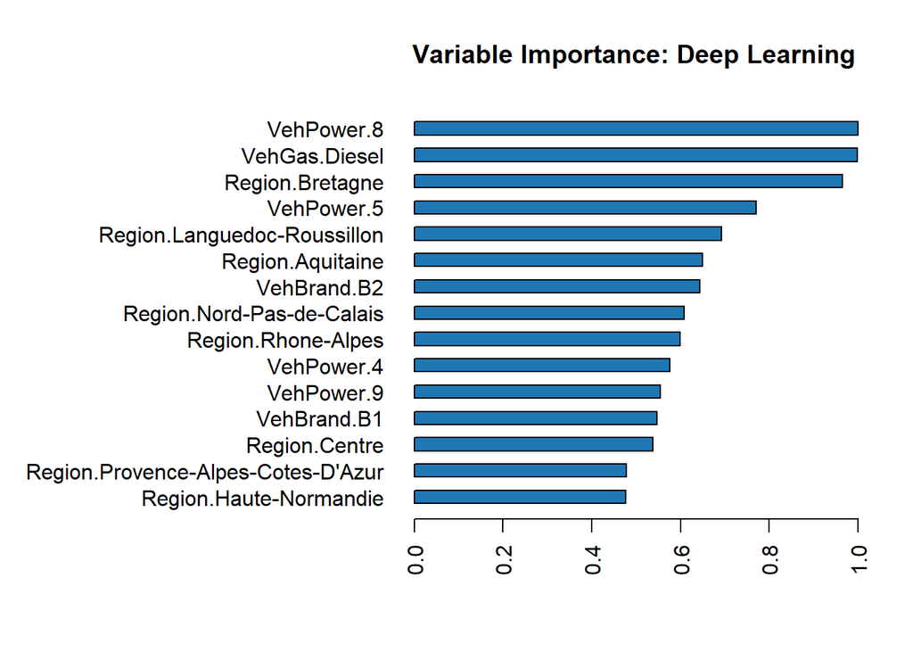

|  | in_sample | out_of_sample |
| --- | --- | --- |
| Mean Poisson Deviance | 32.15 | 31.32 |

## 4.3 Random Grid Search

Il tempo massimo di esecuzione è posto pari a 15 minuti e il numero massimo di modelli stimati pari a 10. Si ottimizzano il numero di neuroni nell’hidden layer (10, 20, 30), il tasso di apprendimento (0.001, 0.005, 0.01) e la regolarizzazione l2 ($0, 10^{-3}, 10^{-5}$). Anche in questo caso, si impone un tasso di dropout del 2% nell’input layer e del 5% nell’hidden layer.

```
## Hyper-Parameter Search Summary: ordered by increasing residual_deviance
##   hidden     l2  rate
## 1   [20]    0.0 0.001
## 2   [30]    0.0 0.005
## 3   [10]    0.0  0.01
## 4   [30] 1.0E-5  0.01
##                                                             model_ids
## 1 Grid_DeepLearning_learn_sid_9dcd_57_model_R_1615711610160_8_model_3
## 2 Grid_DeepLearning_learn_sid_9dcd_57_model_R_1615711610160_8_model_2
## 3 Grid_DeepLearning_learn_sid_9dcd_57_model_R_1615711610160_8_model_1
## 4 Grid_DeepLearning_learn_sid_9dcd_57_model_R_1615711610160_8_model_4
##     residual_deviance
## 1  0.4156494524603463
## 2 0.41570410203697844
## 3  0.4165964962455373
## 4  0.4195795576311968
```

Si ottiene una performance out of sample migliore grazie al tuning degli iperparametri.

|  | in sample | out of sample |
| --- | --- | --- |
| Mean Poisson Deviance | 31.99 | 31.17 |

## 4.4 Shallow Neural Network con Keras

Keras è una API per le reti neurali che può essere eseguita sia sulla CPU (default) che sulla GPU. L’interfaccia R di Keras si appoggia al motore backend di TensorFlow di default.

Si definisce un architettura identica a quella dell’esempio precedente (fully-connected, feed-forward shallow network con 20 neuroni nell’hidden layer, allenato su 100 epoche).

Poichè Keras permette di scegliere la funzione di attivazione per l’output layer, si utilizza una funzione esponenziale al fine di garantire che la frequenza sinistri sia strettamente positiva.

Per evitare di calcolare il gradiente sull’intero dataset, si suddivide il training set in blocchi di osservazioni selezionate randomicamente (batch gradient descent).

I pesi dell’output layer $\omega^{K+1}_j$ sono inizializzati a zero, mentre l’intercetta $\omega^{K+1}_0$ è inizializzata al modello benchmark (2.3).

Inoltre, si selezionano i parametri ottimali fra le seguenti alternative in base al valore della loss out of sample:

| Parametro | Alternative |
| --- | --- |
| Solver | sgd, adagrad, adadelta, rmsprop, adam, adamax, nadam |
| Attivazione | sigmoid, hyperbolic tangent |
| Nr neuroni | (5, 10, 20, 30) |
| Batch Size | (5, 10, 50, 100, 200, 500, 1000) |
| Epochs | (100, 200, 500, 1000) |

Table 4.1: TanH

|  | in sample | out of sample |
| --- | --- | --- |
| sgd | 31.91 | 31.09 |
| adagrad | 31.50 | 30.75 |
| adadelta | 31.50 | 30.75 |
| rmsprop | 31.21 | 30.51 |
| adam | 31.04 | 30.42 |
| adamax | 30.98 | 30.38 |
| nadam | 30.86 | 30.32 |

Table 4.1: Sigmoid

|  | in sample | out of sample |
| --- | --- | --- |
| sgd | 32.10 | 31.30 |
| adagrad | 32.00 | 31.20 |
| adadelta | 32.00 | 31.20 |
| rmsprop | 31.37 | 30.65 |
| adam | 31.30 | 30.58 |
| adamax | 31.28 | 30.57 |
| nadam | 31.22 | 30.52 |

Table 4.2: Selezione del batch size

| numerosità batch | GD steps per epoca | run time (secs) | loss in sample | loss out of sample |
| --- | --- | --- | --- | --- |
| 122042.40 | 5 | 13.93 | 31.45 | 30.71 |
| 61021.20 | 10 | 15.10 | 31.89 | 31.10 |
| 12204.24 | 50 | 22.76 | 31.36 | 30.63 |
| 6102.12 | 100 | 29.86 | 31.32 | 30.61 |
| 3051.06 | 200 | 43.18 | 31.19 | 30.50 |
| 1220.42 | 500 | 1.42 | 31.00 | 30.41 |
| 610.21 | 1000 | 2.44 | 30.99 | 30.37 |

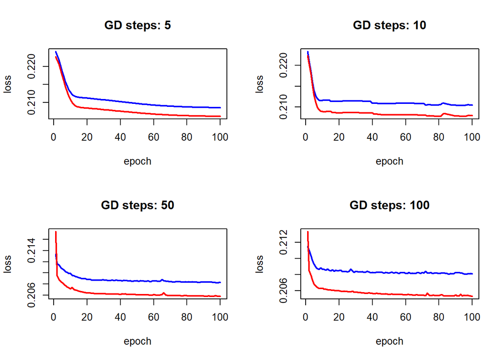

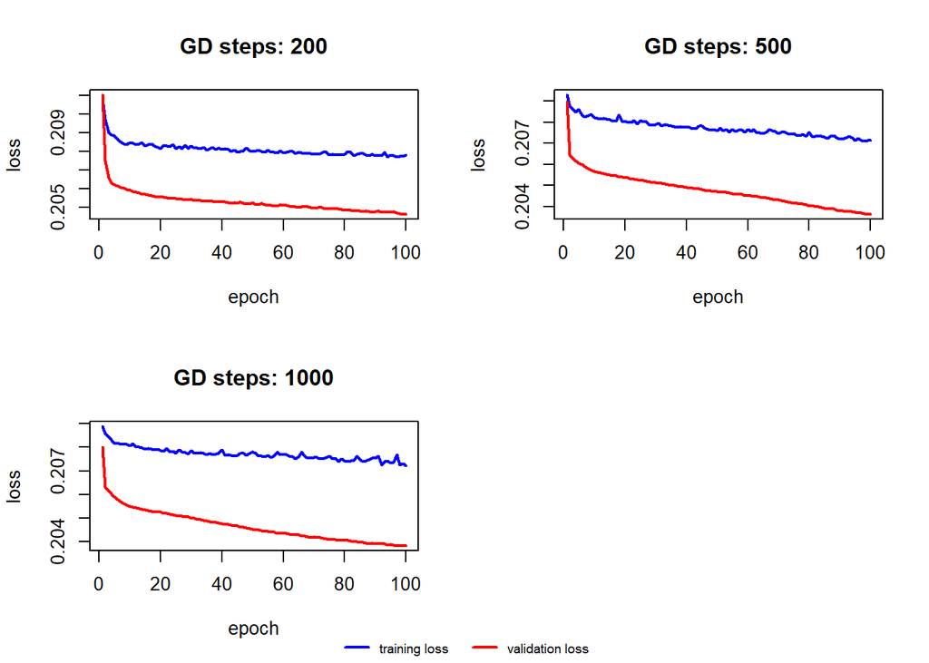

Table 4.3: Selezione del numero di neuroni

| numero di neuroni | run time (secs) | loss in sample | loss out of sample |
| --- | --- | --- | --- |
| 5 | 2.66 | 31.23 | 30.58 |
| 10 | 2.75 | 30.98 | 30.32 |
| 20 | 2.85 | 30.84 | 30.27 |
| 30 | 2.84 | 30.90 | 30.41 |

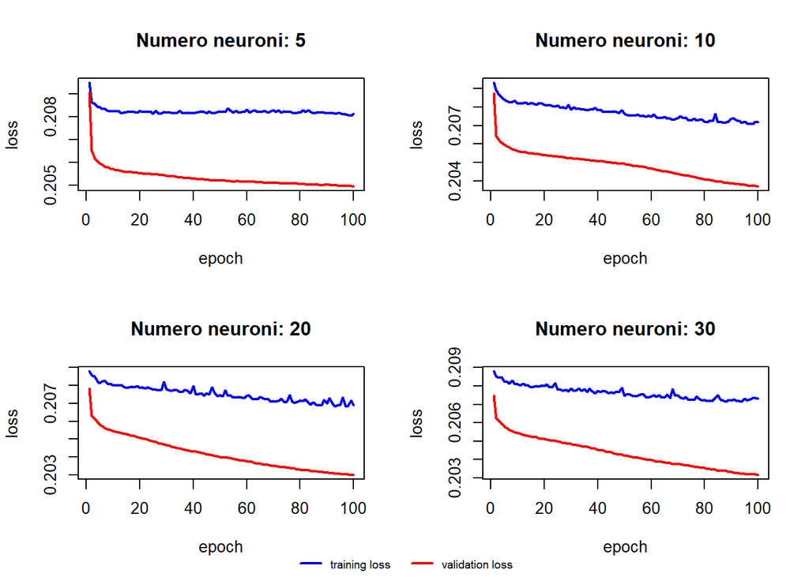

Table 4.4: Selezione del numero di epoche

| epoche | run time (secs) | loss in sample | loss out of sample |
| --- | --- | --- | --- |
| 100 | 2.61 | 30.94 | 30.36 |
| 200 | 5.08 | 30.70 | 30.21 |
| 500 | 12.87 | 30.40 | 29.99 |
| 1000 | 25.84 | 30.39 | 30.11 |

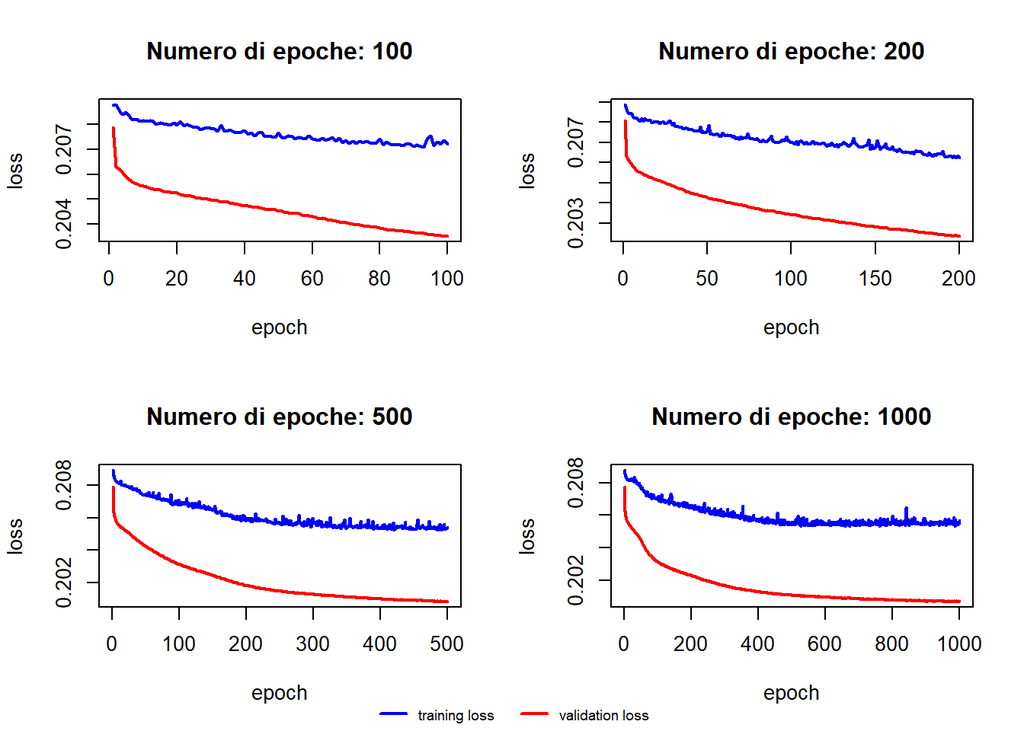

# 5 Deep Neural Network con Keras

## 5.1 Early stopping

Si allena una rete neurale con 3 hidden layer con rispettivamente 20, 15 e 10 nodi e una funzione di attivazione hyperbolic tangent. Si utilizza l’ottimizzatore ‘nadam’ su 1000 epoche con batches da 6000 osservazioni.

Poichè i modelli di deep learning sono particolarmente passibili di overfitting (loss out of sample più elevata di quella in sample), si introduce un criterio di early stopping del gradient descent.

A tal fine, si utilizza una callback del modello in base alla loss sul test set per determinare il numero di epoche ottimale. Nello specifico, si utilizza la funzione “callback_model_checkpoint”, che salva un modello quando la sua loss out of sample è inferiore a quella del modello allenato nell’epoca precedente.

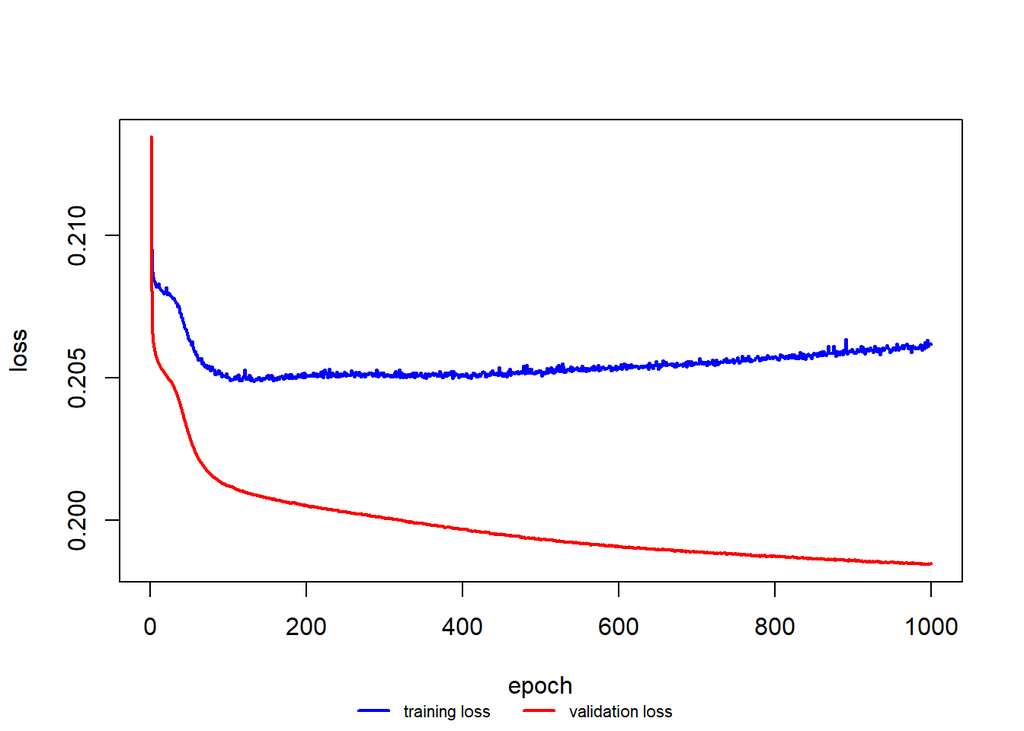

Table 5.1: Mean Poisson Deviance

|  | in sample | out of sample |
| --- | --- | --- |
| senza callback | 30.00 | 30.20 |
| con callback | 30.43 | 29.96 |

## 5.2 Regolarizzazione

Un altro metodo per prevenire l’overfitting è quello di introdurre un termine di regolarizzazione che penalizza i parametri della rete con i valori più estremi.

La Poisson deviance loss regolarizzata diventa

$$L(D, \lambda; \eta) = \frac{1}{n} \sum_{i = 1}^n 2 N_i \left[ \frac{\lambda(x_i)\nu_i}{N_i} - 1 - log \left(\frac{\lambda(x_i)\nu_i}{N_i} \right) \right] + \eta || \theta_{-} ||^p_p$$

con

$$|| \theta ||^p_p = \theta_1^p + ... + \theta_q^p$$

dove $p \geq 1$ e $\eta > 0$ e $\theta_{-}$ rappresenta un subset dello spazio dei parametri $\theta$. Solitamente non tutti i parametri del modello vengono regolarizzati, ma si omettono le intercette $\omega_0^k$.

In questo caso, consideriamo una regolarizzazione l2-norm ($p = 2$) che penalizza i parametri con valori elevati più di quanto penalizzi quelli con valori molto bassi.

La regolarizzazione è applicata ad ogni hidden layer separatamente (escludendo l’output layer e le intercette). Il valore dell’iperparametro $\eta$ che governa la severità della regolarizzazione è posto pari a $10^{-5}$ per tutti i layer.

Poichè i pesi della bias unit sono inizializzati al valore del MLE di $\lambda$, un valore molto elevato di $\eta$ ritornerebbe il modello benchmark (2.3), mentre un valore molto piccolo non correggerebbe l’overfitting.

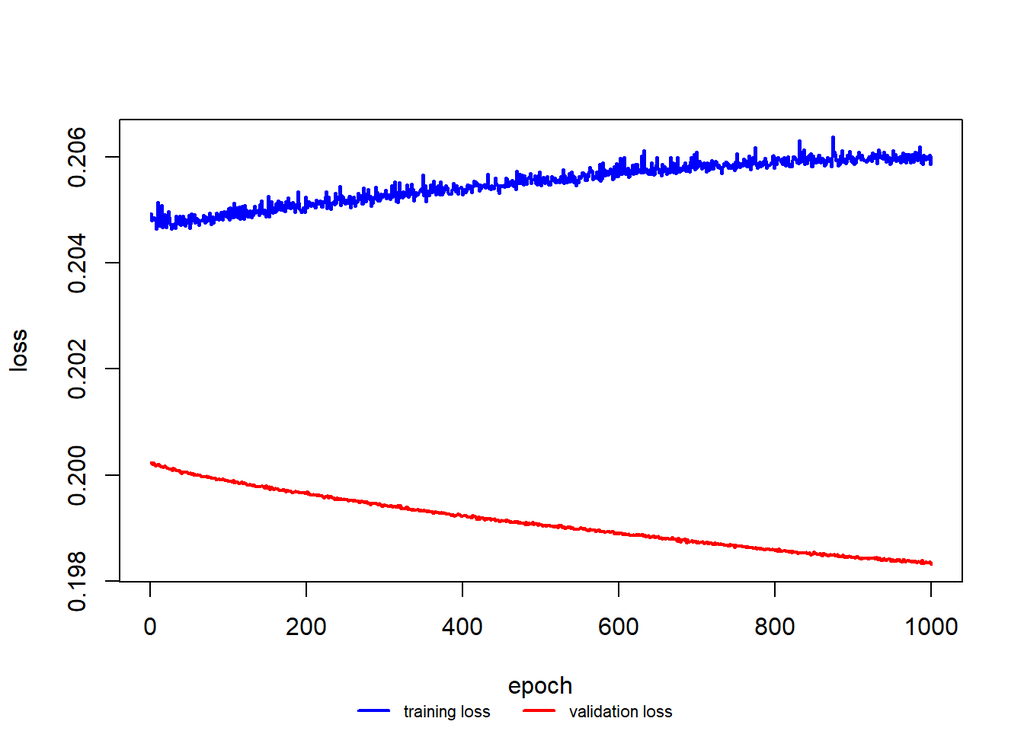

Table 5.2: Mean Poisson Deviance

|  | in sample | out of sample |
| --- | --- | --- |
| senza callback | 29.98 | 30.18 |
| con callback | 30.28 | 30.01 |

## 5.3 Dropout e nomalization layer

Le reti neurali possono soffire del problema del vanishing gradient, dove il gradiente assume valori vicini allo zero in regioni dove la funzione di attivazione è piatta. Per $tanh(x)$ questo può succedere, per esempio, se $x$ è molto elevato. Il deep learning esacerba questo problema poichè, utilizzando la chain rule, si calcolano prodotti di valori potenzialmente molto piccoli.

Il problema del vanishing gradient è evitato aggiungendo alla rete dei layer di normalizzazione, che garantiscono che gli input di ciascun hidden layer abbiano media zero e varianza unitaria.

Inoltre, si aggiungono dei layer di dropout con probabilità 1%, 2%, 5%, e 10%.

Table 5.3: Mean Poisson Deviance (con callback)

| dropout rate | in sample | out of sample |
| --- | --- | --- |
| 0.01 | 30.23 | 29.88 |
| 0.02 | 30.31 | 29.87 |
| 0.05 | 30.17 | 29.89 |
| 0.10 | 30.24 | 29.94 |

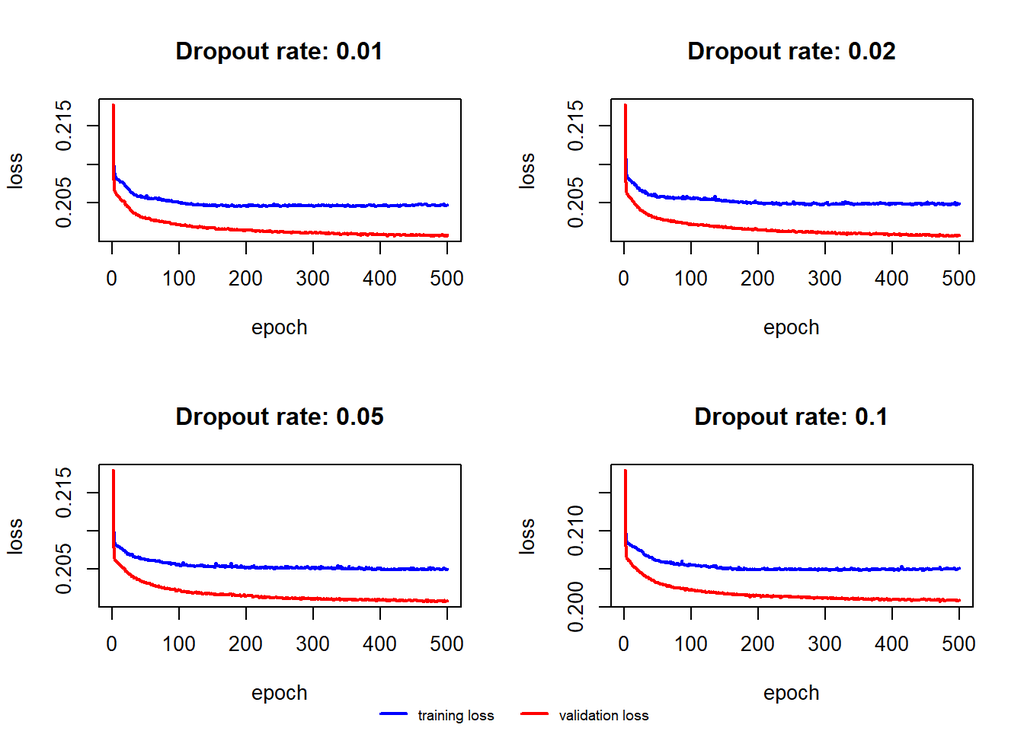

# 6 Previsioni out-of-sample e loss media

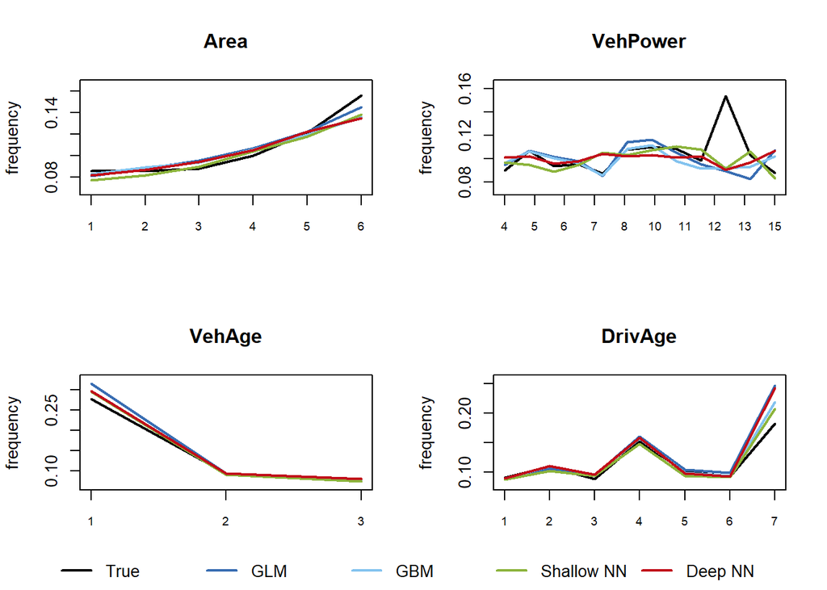

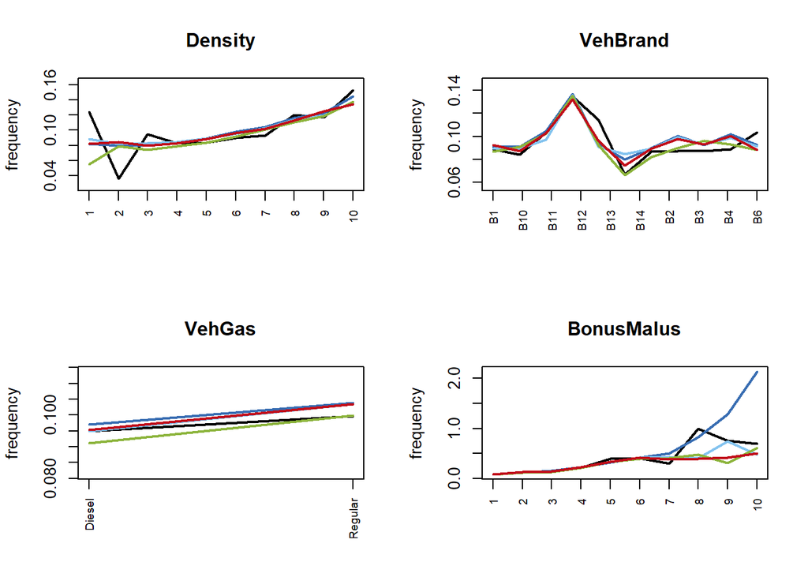

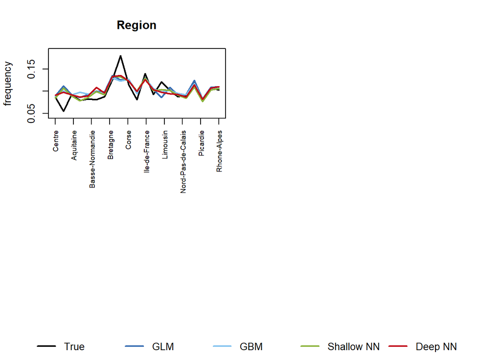

Table 6.1: Poisson Deviance Loss

|  | in sample | out of sample |
| --- | --- | --- |
| Benchmark | 33.10 | 32.40 |
| GLM | 31.41 | 30.92 |
| GBM | 30.12 | 29.94 |
| GBM random search | 30.12 | 30.28 |
| Shallow NN | 30.39 | 30.11 |
| Shallow NN random search | 31.99 | 31.17 |
| Deep NN | 30.43 | 29.96 |
| Deep NN regolarizzazione | 30.28 | 30.01 |
| Deep NN dropout + normalizzazione | 30.23 | 29.88 |

# 7 Riferimenti bibliografici

Noll, A., Salzmann, R., & Wuthrich, M. V. (2020). *Case study: French motor third-party liability claims.* Available at SSRN 3164764.

Ferrario, A., Noll, A., & Wuthrich, M. V. (2020). *Insights from inside neural networks.* Available at SSRN 3226852.

Wüthrich, M.V., Buser, C. (2016). *Data Analytics for Non-Life Insurance Pricing*. SSRN 2870308.